# Linear Regression

In the following recitation, we will be exploring linear regression through two datasets you may be familiar with by now: the College dataset and the Boston dataset.

Packages we will be using:

- StatsModels
  - Provides Statistics
  - R-like Structure
- Scikit-learn
  - Provides more control
  - Not as easy to use (you'll get used to it)
  - Optimized to handle larger datasets better

## College Dataset

Let's assume the true model is given by,

$$ \text{Graduation Rate} \approx \beta_0+\beta_1 X_{\text{Top25perc}}+\epsilon$$

Estimated model through linear regression,

$$ \hat{y_\text{Graduation Rate}} = \hat{\beta_0}+\hat{\beta_1} X_{\text{Top25perc}}$$

```python
#Import required Libraries

#Data Wrangling
import numpy as np
import pandas as pd

#Plotting
import matplotlib as mpl
import matplotlib.pyplot as plt
import seaborn as sns

#Linear Models
from sklearn.linear_model import LinearRegression
import statsmodels.formula.api as smf
import statsmodels.api as sm

#Modeling
from statsmodels.sandbox.regression.predstd import wls_prediction_std
from statsmodels.graphics.gofplots import ProbPlot
from statsmodels.stats.outliers_influence import variance_inflation_factor

%matplotlib inline
import warnings
warnings.filterwarnings("ignore")

blue = '#008FD5'
red = '#FF2700'
green = '#77AB43'
```

```python
#Import DataSet as a pandas DataFrame
data = pd.read_csv('College.csv')

#Rename columns into standard form, the ols package understands _ not .
data = data.rename(columns = {'Grad.Rate':'Grad_Rate',
                              'S.F.Ratio': 'S_F_Ratio',
                              'perc.alumni':'perc_alumni',
                              'Room.Board':'Room_Board',
                              'F.Undergrad':'F_Undergrad',
                              'P.Undergrad':'P_Undergrad'})
data.head() #Preview head and get a feel for the data
```

|  | Private | Apps | Accept | Enroll | Top10perc | Top25perc | F_Undergrad | P_Undergrad | Outstate | Room_Board | Books | Personal | PhD | Terminal | S_F_Ratio | perc_alumni | Expend | Grad_Rate | Names |
| --- | --- | --- | --- | --- | --- | --- | --- | --- | --- | --- | --- | --- | --- | --- | --- | --- | --- | --- | --- |
| 0 | Yes | 1660 | 1232 | 721 | 23 | 52 | 2885 | 537 | 7440 | 3300 | 450 | 2200 | 70 | 78 | 18.1 | 12 | 7041 | 60 | Abilene Christian University |
| 1 | Yes | 2186 | 1924 | 512 | 16 | 29 | 2683 | 1227 | 12280 | 6450 | 750 | 1500 | 29 | 30 | 12.2 | 16 | 10527 | 56 | Adelphi University |
| 2 | Yes | 1428 | 1097 | 336 | 22 | 50 | 1036 | 99 | 11250 | 3750 | 400 | 1165 | 53 | 66 | 12.9 | 30 | 8735 | 54 | Adrian College |
| 3 | Yes | 417 | 349 | 137 | 60 | 89 | 510 | 63 | 12960 | 5450 | 450 | 875 | 92 | 97 | 7.7 | 37 | 19016 | 59 | Agnes Scott College |
| 4 | Yes | 193 | 146 | 55 | 16 | 44 | 249 | 869 | 7560 | 4120 | 800 | 1500 | 76 | 72 | 11.9 | 2 | 10922 | 15 | Alaska Pacific University |

```python
data2 = data.copy() #Must use copy() to assign to a new variable, var2=var1 only creates a reference
data2['Accept_Rate'] = data2['Accept']/data2['Apps']
```

### Stats Models

```python
# Statsmodels ols
fit0 = smf.ols('Grad_Rate~Top25perc',data = data2).fit()
print(fit0.summary())
```

```
                            OLS Regression Results
==============================================================================
Dep. Variable:              Grad_Rate   R-squared:                       0.228
Model:                            OLS   Adj. R-squared:                  0.227
Method:                 Least Squares   F-statistic:                     228.6
Date:                Mon, 25 May 2020   Prob (F-statistic):           1.87e-45
Time:                        10:44:13   Log-Likelihood:                -3211.1
No. Observations:                 777   AIC:                             6426.
Df Residuals:                     775   BIC:                             6435.
Df Model:                           1
Covariance Type:            nonrobust
==============================================================================
                 coef    std err          t      P>|t|      [0.025      0.975]
------------------------------------------------------------------------------
Intercept     42.3651      1.621     26.137      0.000      39.183      45.547
Top25perc      0.4140      0.027     15.120      0.000       0.360       0.468
==============================================================================
Omnibus:                        6.261   Durbin-Watson:                   1.784
Prob(Omnibus):                  0.044   Jarque-Bera (JB):                8.055
Skew:                          -0.062   Prob(JB):                       0.0178
Kurtosis:                       3.483   Cond. No.                         177.
==============================================================================

Warnings:
[1] Standard Errors assume that the covariance matrix of the errors is correctly specified.
```

```python
#Stats Models OLS
X = data2['Top25perc']
X = sm.add_constant(X) #Using this function, we need to add a constant to estimate beta_0
y = data2['Grad_Rate']
fit1 = sm.OLS(y,X).fit() #The Fit object contains a lot of important information we explore below
print(fit1.summary())
```

```
                            OLS Regression Results
==============================================================================
Dep. Variable:              Grad_Rate   R-squared:                       0.228
Model:                            OLS   Adj. R-squared:                  0.227
Method:                 Least Squares   F-statistic:                     228.6
Date:                Mon, 25 May 2020   Prob (F-statistic):           1.87e-45
Time:                        10:44:13   Log-Likelihood:                -3211.1
No. Observations:                 777   AIC:                             6426.
Df Residuals:                     775   BIC:                             6435.
Df Model:                           1
Covariance Type:            nonrobust
==============================================================================
                 coef    std err          t      P>|t|      [0.025      0.975]
------------------------------------------------------------------------------
const         42.3651      1.621     26.137      0.000      39.183      45.547
Top25perc      0.4140      0.027     15.120      0.000       0.360       0.468
==============================================================================
Omnibus:                        6.261   Durbin-Watson:                   1.784
Prob(Omnibus):                  0.044   Jarque-Bera (JB):                8.055
Skew:                          -0.062   Prob(JB):                       0.0178
Kurtosis:                       3.483   Cond. No.                         177.
==============================================================================

Warnings:
[1] Standard Errors assume that the covariance matrix of the errors is correctly specified.
```

### Sci Kit Learn

```python
# Scikitlearn
X = data2[['Top25perc']]
y = data2['Grad_Rate']
model = LinearRegression(fit_intercept = True)
fit2 = model.fit(X,y)
```

We can use the dir() function in order to find out what other pieces of information are stored in model.fit().

```python
dir(fit2)
```

```
['__abstractmethods__',
 '__class__',
 '__delattr__',
 '__dict__',
 '__dir__',
 '__doc__',
 '__eq__',
 '__format__',
 '__ge__',
 '__getattribute__',
 '__getstate__',
 '__gt__',
 '__hash__',
 '__init__',
 '__init_subclass__',
 '__le__',
 '__lt__',
 '__module__',
 '__ne__',
 '__new__',
 '__reduce__',
 '__reduce_ex__',
 '__repr__',
 '__setattr__',
 '__setstate__',
 '__sizeof__',
 '__str__',
 '__subclasshook__',
 '__weakref__',
 '_abc_impl',
 '_decision_function',
 '_estimator_type',
 '_get_param_names',
 '_get_tags',
 '_more_tags',
 '_preprocess_data',
 '_residues',
 '_set_intercept',
 'coef_',
 'copy_X',
 'fit',
 'fit_intercept',
 'get_params',
 'intercept_',
 'n_jobs',
 'normalize',
 'predict',
 'rank_',
 'score',
 'set_params',
 'singular_']
```

```python
print('Coefficient:',fit2.coef_)
print('Intercept',fit2.intercept_)
```

```
Coefficient: [0.41397069]
Intercept 42.36514137548303
```

```python
X = data2['Top25perc']
print('Before New Axis:',X.shape)
X = X[:,np.newaxis]
print('After new axis:',X.shape)

X = data2[['Top25perc']]
print('Shortcut:',X.shape)
```

```
Before New Axis: (777,)
After new axis: (777, 1)
Shortcut: (777, 1)
```

- Looking at the results above, we see that the estimates, $\hat{\beta_0} = 42.3651$, $\hat{\beta_1} = 0.4140$.
- This means that for every unit ($1\%$) increase in **Top24perc** there is a $0.4140\%$ increase in the **graduation rate**.

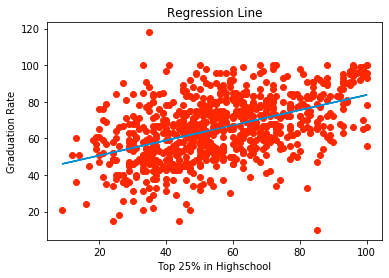

```python
plt.plot(data2['Top25perc'],data2['Grad_Rate'],'o',color = red);
plt.plot(data2['Top25perc'],fit0.fittedvalues,color = blue);
plt.xlabel('Top 25% in Highschool');
plt.ylabel('Graduation Rate');
plt.title('Regression Line');
```

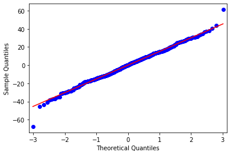

```python
#Plotting QQ Plot
sm.qqplot(fit0.resid,line = 's');
```

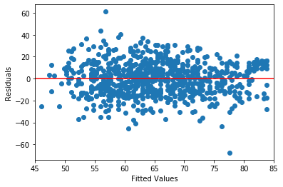

```python
#Plotting residual plot
plt.plot(fit0.fittedvalues,fit0.resid,'o')
plt.plot([0,85],[0,0],'r') #Plots straight line
plt.xlim([45,85])#Control x Axis
plt.xlabel('Fitted Values')
plt.ylabel('Residuals')
plt.show()
```

We now cover some important statistical terms such as $R^2$ and Residual Standard Error.

$$ \text{RSS (Residual Sum of Squares)} = \sum_{i = 1}^{N}(y_i-\hat{y_i})^2$$$$\text{RSE (Residual Standard Error)} = \sqrt{\frac{RSS}{DF}} = \sqrt{\frac{RSS}{n-p-1}} = \sqrt{\frac{RSS}{n-2}}$$

Where DF is the degrees of freedom

$$\text{TSS (Total Sum of Squares)} = \sum_{i = 1}^{N}(y_i-\mu)^2$$

Where $\mu$ is the average of $y$.

Now the famous $R^2$ is,

$$R^2 = \frac{TSS-RSS}{TSS}$$

```python
#Programming the above formulas
RSS = np.sum(fit1.resid**2) #Residuals is y_i - \hat{y_i}
RSE = np.sqrt(RSS/fit1.df_resid)
print("RSE:",RSE)
TSS = np.sum((data2['Grad_Rate']-np.average(data2['Grad_Rate']))**2)
Rsquared = (TSS-RSS)/TSS
print("R^2:",Rsquared)
```

```
RSE: 15.104659114441102
R^2: 0.2277973098679033
```

```python
#The above code is shown for illustrative reasons, we can much easily access R^2
print("R^2:",fit1.rsquared)
```

```
R^2: 0.22779730986790325
```

```python
#Accessing RSE is also relatively easy
print("RSE:",np.sqrt(fit1.scale))
```

```
RSE: 15.104659114441102
```

Residual Standard Error (RSE) is important because this is the estimate of $\sigma$ when we assumed the error term $\epsilon$ to be normally distributed with $N(0,\sigma)$

### Confidence Intervals

- $\hat{\beta}$ are the mean estimates
- Every estimate needs a confidence interval (Obtained from its mean and standard error)
- Confidence Interval $$\mu \pm (z\times \text{Standard Error})$$

### 95% Confidence intervals

$\beta_0$:

$$42.3651 \pm (1.96 \times 1.621) = [39.18,45.54]$$

$\beta_1$:

$$0.4140 \pm (1.96 \times 0.027) = [0.36,0.46]$$

We may interpret this as, with a 95% probability the true value of $\beta_1$ is contained within the interval $[0.36,0.46]$.

### Hypothesis Testing and p-values

- Is $\hat{\beta_1}$ statistically significant?

### Problem Formulation

- Null Hypothesis
  - $H_0:$ No relationship between $X$ and $Y$
  - $H_0: \hat{\beta_1} = 0$
- Alternative Hypothesis
  - $H_a:$ There is some relationship between $X$ and $Y$
  - $H_a: \hat{\beta_1} \neq 0$

### Interpretation

- A small **p-value**:
  - We reject the null hypothesis at a **particular significance level**
  - There is a relationship between Top25perc and Grad_Rate at a **particular significance level**
- A large **p-value**
  - We fail to reject the null hypothesis at a **particular significance level**
  - There is no association between Top25perc and Grad_Rate at a **particular significance level**

**We never accept the null hypothesis, we only fail to reject it**

```python
#P-values:
## The summary tables above show it as 0 for both coefficients, however this is impossible. The numbers are just small
fit0.pvalues
```

```
Intercept    1.791766e-108
Top25perc     1.872333e-45
dtype: float64
```

The interpretation of the p-value is, at a 0.05 level, we reject the null hypothesis. Hence, at a 0.05 level we believe there to be a significant relationship between Top25perc and Grad_rate because $0.05>1.87\times 10^{-45}$

### Prediction Intervals

- Our model is only as good as its predictive capabilities
- Predictions are estimates too
  - Every estimate needs a confidence interval

### Prediction

- "Unknown University" with a feature "Top25perc = 60%"

$$\text{Grad_Rate} = 42.3651+(0.4140\times 60) = 67.2051\%$$

```python
#If predicting using fit0
new = pd.DataFrame({'Top25perc':[60]}) #Data Frame with the one new unknown university
print('Unknown University Grad Rate: ',fit0.predict(new)[0]) #Difference from our calculation due to rounding
```

```
Unknown University Grad Rate:  67.20338257756316
```

```python
#If predicting using fit1
new = pd.DataFrame({'Top25perc':[60]}) #Data Frame with the one new unknown university
new = sm.add_constant(new,has_constant='add')
mean = fit1.predict(new)[0]
print('Unknown University Grad Rate: {0}'.format(mean)) #Difference from our calculation due to rounding
```

```
Unknown University Grad Rate: 67.20338257756316
```

### Intervals

- $95\%$ confidence interval $$\mu \pm (1.96\times RSE) \approx \mu \pm (2\times RSE)$$

```python
#Prediction intervals
sigma = np.sqrt(fit0.scale) #Calculate RSE
pred_min = mean - 2*sigma
pred_max = mean + 2*sigma

print('Prediction Interval: [{0},{1}]'.format(pred_min,pred_max))
```

```
Prediction Interval: [36.99406434868096,97.41270080644537]
```

```python
# Statsmodels ols RECAP from recitation 3
fit0 = smf.ols('Grad_Rate~Top25perc',data = data2).fit()
print(fit0.summary())
```

```
                            OLS Regression Results
==============================================================================
Dep. Variable:              Grad_Rate   R-squared:                       0.228
Model:                            OLS   Adj. R-squared:                  0.227
Method:                 Least Squares   F-statistic:                     228.6
Date:                Mon, 25 May 2020   Prob (F-statistic):           1.87e-45
Time:                        10:44:14   Log-Likelihood:                -3211.1
No. Observations:                 777   AIC:                             6426.
Df Residuals:                     775   BIC:                             6435.
Df Model:                           1
Covariance Type:            nonrobust
==============================================================================
                 coef    std err          t      P>|t|      [0.025      0.975]
------------------------------------------------------------------------------
Intercept     42.3651      1.621     26.137      0.000      39.183      45.547
Top25perc      0.4140      0.027     15.120      0.000       0.360       0.468
==============================================================================
Omnibus:                        6.261   Durbin-Watson:                   1.784
Prob(Omnibus):                  0.044   Jarque-Bera (JB):                8.055
Skew:                          -0.062   Prob(JB):                       0.0178
Kurtosis:                       3.483   Cond. No.                         177.
==============================================================================

Warnings:
[1] Standard Errors assume that the covariance matrix of the errors is correctly specified.
```

### Multiple Regression

$$\hat{y}_{\text{Grad_Rate}} = \hat{\beta_0}+(\hat{\beta_1}X_{\text{Top25perc}})+(\hat{\beta_2}X_{\text{Top10perc}})+\epsilon$$

```python
#We use  ols because Anova doesnt work with OLS. Dont know why and its annoying!

fit2 = smf.ols('Grad_Rate~Top25perc+Top10perc',data = data2).fit()
print(fit2.summary())
```

```
                            OLS Regression Results
==============================================================================
Dep. Variable:              Grad_Rate   R-squared:                       0.251
Model:                            OLS   Adj. R-squared:                  0.249
Method:                 Least Squares   F-statistic:                     129.9
Date:                Mon, 25 May 2020   Prob (F-statistic):           2.31e-49
Time:                        10:44:14   Log-Likelihood:                -3199.1
No. Observations:                 777   AIC:                             6404.
Df Residuals:                     774   BIC:                             6418.
Df Model:                           2
Covariance Type:            nonrobust
==============================================================================
                 coef    std err          t      P>|t|      [0.025      0.975]
------------------------------------------------------------------------------
Intercept     47.9006      1.953     24.529      0.000      44.067      51.734
Top25perc      0.1518      0.060      2.543      0.011       0.035       0.269
Top10perc      0.3300      0.067      4.926      0.000       0.199       0.462
==============================================================================
Omnibus:                        5.420   Durbin-Watson:                   1.773
Prob(Omnibus):                  0.067   Jarque-Bera (JB):                6.951
Skew:                           0.022   Prob(JB):                       0.0309
Kurtosis:                       3.461   Cond. No.                         246.
==============================================================================

Warnings:
[1] Standard Errors assume that the covariance matrix of the errors is correctly specified.
```

### Important Points

Notice that in the model above we have only added one extra feature. Here are a few important points to pay close attention to,

### Interpretation

- For every unit increase in *Top25perc* the graduation rate increases by 0.1518% while holding *Top10perc* **constant**.
- For every unit increase in *Top10perc* the graduation rate increases by 0.0.33% while holding *Top25perc* **constant**.

### Hypothsis Testing

The Null hypothesis we test for,

1. $H_0: \beta_1 = 0$
2. $H_0: \beta_2 = 0$
3. $H_0: \beta_1=\beta_2 = 0$

```python
fit2.pvalues
```

```
Intercept    9.421877e-99
Top25perc    1.118502e-02
Top10perc    1.026997e-06
dtype: float64
```

Looking at the pvalues we can easily test null hypothesis 1. ($\beta_1 = 0$) and 2. ($\beta_2 = 0$).

- We reject the null hypthesis that $\beta_1 = 0$ at a 0.05 level. Because 0.05>1.11e-2
- We reject the null hypothesis that $\beta_2 = 0$ at a 0.05 level. Because 0.05>>1.027e-6

Testing the null hypothesis for 3.($H_0: \beta_1=\beta_2 = 0$) is not as straight forward.

- We first fit a new model setting $\beta_1=\beta_2 = 0$ which results in $\hat{y} = \beta_0$. We then perform a type 1 analysis of variance (Anova) test. As shown below:

```python
#Fit a model with only the intercept
fit2_1 = smf.ols('Grad_Rate~1',data = data2).fit() #Fit only a constant
#print(fit2_1.summary())
#Anova type 1 test
print(((np.sum(fit2_1.resid**2)-np.sum(fit2.resid**2))/2)/((np.sum(fit2.resid**2))/(777-1-2)))

sm.stats.anova_lm(fit2_1,fit2,typ = 1) #Throws warning due to intercept
```

```
129.87518515216715
```

|  | df_resid | ssr | df_diff | ss_diff | F | Pr(>F) |
| --- | --- | --- | --- | --- | --- | --- |
| 0 | 776.0 | 228977.204633 | 0.0 | NaN | NaN | NaN |
| 1 | 774.0 | 171442.121306 | 2.0 | 57535.083327 | 129.875185 | 2.311449e-49 |

**Hypothesis test 3.**

We can reject the null hypothesis that $\beta_1=\beta_2 = 0$ at a 0.05 level because 0.05>>2.31e-49.

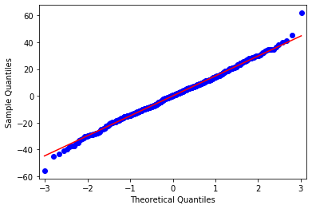

```python
sm.qqplot(fit2.resid,line = 's');
```

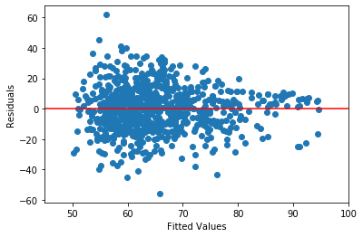

```python
plt.plot(fit2.fittedvalues,fit2.resid,'o')
plt.plot([0,100],[0,0],'r') #Plots straight line
plt.xlim([45,100])#Control x Axis
plt.xlabel('Fitted Values')
plt.ylabel('Residuals')
plt.show()
```

### Large Multiregression Model

```python
#We first drop the predicting variable
# We Drop Names because it is unique to every observation, this introduces many degrees of freedom
#This is an important point. If a dataset contains a unique identifier like university name in this case, drop it
#We then drop Private because in this example we only want to consider continuous and not categorical variables

X = data2.drop(['Grad_Rate','Names','Private'],axis = 1)
all_columns = '+'.join(X.columns)
my_formula = 'Grad_Rate~'+all_columns
print(my_formula)
fit3 = smf.ols(my_formula,data = data2).fit()
print(fit3.summary())
#The estimated coefficients, betas are shown below
```

```
Grad_Rate~Apps+Accept+Enroll+Top10perc+Top25perc+F_Undergrad+P_Undergrad+Outstate+Room_Board+Books+Personal+PhD+Terminal+S_F_Ratio+perc_alumni+Expend+Accept_Rate
                            OLS Regression Results
==============================================================================
Dep. Variable:              Grad_Rate   R-squared:                       0.464
Model:                            OLS   Adj. R-squared:                  0.452
Method:                 Least Squares   F-statistic:                     38.58
Date:                Mon, 25 May 2020   Prob (F-statistic):           1.27e-90
Time:                        10:44:15   Log-Likelihood:                -3069.6
No. Observations:                 777   AIC:                             6175.
Df Residuals:                     759   BIC:                             6259.
Df Model:                          17
Covariance Type:            nonrobust
===============================================================================
                  coef    std err          t      P>|t|      [0.025      0.975]
-------------------------------------------------------------------------------
Intercept      49.6488      6.655      7.460      0.000      36.584      62.714
Apps            0.0003      0.001      0.612      0.541      -0.001       0.001
Accept          0.0008      0.001      0.772      0.441      -0.001       0.003
Enroll          0.0019      0.002      0.835      0.404      -0.003       0.006
Top10perc       0.0681      0.072      0.952      0.342      -0.072       0.209
Top25perc       0.1186      0.055      2.148      0.032       0.010       0.227
F_Undergrad    -0.0006      0.000     -1.448      0.148      -0.001       0.000
P_Undergrad    -0.0016      0.000     -4.120      0.000      -0.002      -0.001
Outstate        0.0012      0.000      5.344      0.000       0.001       0.002
Room_Board      0.0019      0.001      3.164      0.002       0.001       0.003
Books          -0.0030      0.003     -1.018      0.309      -0.009       0.003
Personal       -0.0015      0.001     -2.010      0.045      -0.003   -3.58e-05
PhD             0.0651      0.056      1.153      0.249      -0.046       0.176
Terminal       -0.0885      0.062     -1.432      0.152      -0.210       0.033
S_F_Ratio      -0.0200      0.158     -0.126      0.900      -0.330       0.290
perc_alumni     0.2967      0.049      6.071      0.000       0.201       0.393
Expend         -0.0005      0.000     -3.275      0.001      -0.001      -0.000
Accept_Rate   -12.3132      4.724     -2.607      0.009     -21.587      -3.040
==============================================================================
Omnibus:                       36.346   Durbin-Watson:                   2.005
Prob(Omnibus):                  0.000   Jarque-Bera (JB):               97.726
Skew:                           0.162   Prob(JB):                     6.01e-22
Kurtosis:                       4.707   Cond. No.                     2.85e+05
==============================================================================

Warnings:
[1] Standard Errors assume that the covariance matrix of the errors is correctly specified.
[2] The condition number is large, 2.85e+05. This might indicate that there are
strong multicollinearity or other numerical problems.
```

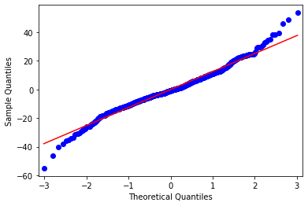

```python
sm.qqplot(fit3.resid,line = 's');
```

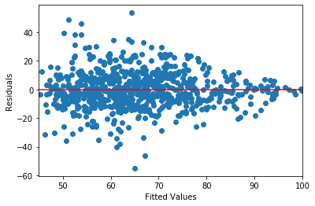

```python
plt.plot(fit3.fittedvalues,fit3.resid,'o')
plt.plot([0,100],[0,0],'r') #Plots straight line
plt.xlim([45,100])#Control x Axis
plt.xlabel('Fitted Values')
plt.ylabel('Residuals')
plt.show()
```

### Moving Beyond Continuous Variables

- Categorical Variables
  - Does it have order?
- Choosing categorical features may not be obvious
- Caution: Pay attention to degrees of freedom!

### Including Qulitative Variables in Our Model

```python
auto = pd.read_csv('Auto.csv')
```

```python
auto['origin'] = ["American" if i == 1 else 'European' if i==2 else "Japanese" for i in auto['origin']]
```

```python
auto.head()
```

|  | mpg | cylinders | displacement | horsepower | weight | acceleration | year | origin | name |
| --- | --- | --- | --- | --- | --- | --- | --- | --- | --- |
| 0 | 18.0 | 8 | 307.0 | 130 | 3504 | 12.0 | 70 | American | chevrolet chevelle malibu |
| 1 | 15.0 | 8 | 350.0 | 165 | 3693 | 11.5 | 70 | American | buick skylark 320 |
| 2 | 18.0 | 8 | 318.0 | 150 | 3436 | 11.0 | 70 | American | plymouth satellite |
| 3 | 16.0 | 8 | 304.0 | 150 | 3433 | 12.0 | 70 | American | amc rebel sst |
| 4 | 17.0 | 8 | 302.0 | 140 | 3449 | 10.5 | 70 | American | ford torino |

#### One Hot Encoding is the practice of transforming categorical data to numerical data.

$$\hat{Y} = \hat{\beta_0}+\hat{\beta_1}X_{European}+\hat{\beta_2}X_{Japanese}$$

$$X_{\text{European}} = \begin{cases}1,& \text{if origin is European}\\ 0,& \text{if origin is Not European}\end{cases}$$$$X_{\text{Japanese}} = \begin{cases}1,& \text{if origin is Japanese}\\ 0,& \text{if origin is Not Japanese}\end{cases}$$

$$\hat{Y} = \hat{\beta_0}+\hat{\beta_1}X_{European}+\hat{\beta_2}X_{Japanese} = \begin{cases} \hat{\beta_0}&,\text{if American}\\ \hat{\beta_0}+\hat{\beta_1}&,\text{if European}\\ \hat{\beta_0}+\hat{\beta_2}&,\text{if Japanese} \end{cases}$$

```python
fit4 = smf.ols('mpg~C(origin)',data = auto).fit() #Fitting the model
print(fit4.summary()) #Summary Statistics
```

```
                            OLS Regression Results
==============================================================================
Dep. Variable:                    mpg   R-squared:                       0.332
Model:                            OLS   Adj. R-squared:                  0.328
Method:                 Least Squares   F-statistic:                     96.60
Date:                Mon, 25 May 2020   Prob (F-statistic):           8.67e-35
Time:                        10:44:15   Log-Likelihood:                -1282.2
No. Observations:                 392   AIC:                             2570.
Df Residuals:                     389   BIC:                             2582.
Df Model:                           2
Covariance Type:            nonrobust
=========================================================================================
                            coef    std err          t      P>|t|      [0.025      0.975]
-----------------------------------------------------------------------------------------
Intercept                20.0335      0.409     49.025      0.000      19.230      20.837
C(origin)[T.European]     7.5695      0.877      8.634      0.000       5.846       9.293
C(origin)[T.Japanese]    10.4172      0.828     12.588      0.000       8.790      12.044
==============================================================================
Omnibus:                       26.330   Durbin-Watson:                   0.763
Prob(Omnibus):                  0.000   Jarque-Bera (JB):               30.217
Skew:                           0.679   Prob(JB):                     2.74e-07
Kurtosis:                       3.066   Cond. No.                         3.16
==============================================================================

Warnings:
[1] Standard Errors assume that the covariance matrix of the errors is correctly specified.
```

```python
usa = auto[auto['origin'] == "American"]
europe = auto[auto['origin'] == "European"]
japanese = auto[auto['origin'] == "Japanese"]
```

```python
print(usa['mpg'].mean())
print(europe['mpg'].mean())
print(japanese['mpg'].mean())
```

```
20.033469387755098
27.602941176470587
30.450632911392397
```

$$\hat{Y} = \begin{cases}20.03&,\text{if American}\\ 20.03+7.56&,\text{if European}\\ 20.03+10.417 &, \text{if Japanese}\end{cases}$$

### Hypothesis Testing with Categorical Variables

- Can we use the p-values?
- Alternatives?
- Let's try a F-Test using ANOVA (Type 2)

```python
sm.stats.anova_lm(fit4,typ = 2)
```

|  | sum_sq | df | F | PR(>F) |
| --- | --- | --- | --- | --- |
| C(origin) | 7904.291038 | 2.0 | 96.60153 | 8.673818e-35 |
| Residual | 15914.702431 | 389.0 | NaN | NaN |

## Boston Dataset

The sklearn.datasets library contains the Boston dataset, which records the medv (median house value) for 506 neighborhoods around Boston. We will seek to predict MEDV using 13 predictors such as RM (average number of rooms per house), AGE (average age of house), and LSTAT (percent of households with low socioeconomic status).

Here, Boston is a dictionary of the data with keys 'target', 'data' and 'DESCR' (documentation: https://scikit-learn.org/stable/modules/generated/sklearn.datasets.load_boston.html).

```python
from sklearn.datasets import load_boston
boston_dataset = load_boston()
Boston = pd.DataFrame(data = boston_dataset.data, columns = boston_dataset.feature_names)
Boston['MEDV'] = pd.Series(boston_dataset.target)
Boston.head()
```

|  | CRIM | ZN | INDUS | CHAS | NOX | RM | AGE | DIS | RAD | TAX | PTRATIO | B | LSTAT | MEDV |
| --- | --- | --- | --- | --- | --- | --- | --- | --- | --- | --- | --- | --- | --- | --- |
| 0 | 0.00632 | 18.0 | 2.31 | 0.0 | 0.538 | 6.575 | 65.2 | 4.0900 | 1.0 | 296.0 | 15.3 | 396.90 | 4.98 | 24.0 |
| 1 | 0.02731 | 0.0 | 7.07 | 0.0 | 0.469 | 6.421 | 78.9 | 4.9671 | 2.0 | 242.0 | 17.8 | 396.90 | 9.14 | 21.6 |
| 2 | 0.02729 | 0.0 | 7.07 | 0.0 | 0.469 | 7.185 | 61.1 | 4.9671 | 2.0 | 242.0 | 17.8 | 392.83 | 4.03 | 34.7 |
| 3 | 0.03237 | 0.0 | 2.18 | 0.0 | 0.458 | 6.998 | 45.8 | 6.0622 | 3.0 | 222.0 | 18.7 | 394.63 | 2.94 | 33.4 |
| 4 | 0.06905 | 0.0 | 2.18 | 0.0 | 0.458 | 7.147 | 54.2 | 6.0622 | 3.0 | 222.0 | 18.7 | 396.90 | 5.33 | 36.2 |